# Kereszttábla-elemzés, korrespondencia elemzés – 2026-os frissítés

**Feladat:** Végezzük el a kereszttábla-elemzést a friss, 2026. II. negyedévi KSH-foglalkoztatási adatokon, vizsgáljuk meg a nem és a foglalkozás típusa közötti kapcsolatot, majd hasonlítsuk össze az eredményt az órai, 1990-es adatokkal.

A megoldás a feltöltött órai `02_sol.Rmd` felépítéséből indul ki. A friss adatokat a mellékelt `ksh_2026_Q2.xlsx` állomány tartalmazza. Oké, közben feltűnt, hogy csak HTML-t lehet leadni Moodle-ben. Szóval csak azt adom le :)

Munkamenet

1. Szükséges függvénykönyvtárak beolvasása
2. Adatok beolvasása
3. A 2026. II. negyedévi kereszttábla elemzése
4. Összehasonlítás az 1990-es órai adatokkal

# 1 Szükséges függvénykönyvtárak beolvasása

```r
library(readxl) # Excel állományok beolvasása
library(gmodels) # Kereszttáblák kiszámítása
library(vcd) # Eredmények vizualizálása
```

# 2 Adatok beolvasása

A friss adatok forrása a KSH STADAT **20.2.1.15. A foglalkoztatottak száma foglalkozási főcsoport szerint, nemenként, negyedévente – FEOR’08** táblája. A felhasznált időszak **2026. II. negyedév**, a KSH tábla frissítési dátuma **2026. augusztus 14.** A mértékegység ezer fő.

Forrás: https://www.ksh.hu/stadat_files/mun/hu/mun0113.html

A mai FEOR’08-főcsoportok nem azonosak az órai, 1990-es `Szakmunkás – Betanított munkás – Segédmunkás – Szellemi` kategóriákkal. Emiatt kétféle összehasonlítást végzünk:

- a **2026-os részletes kereszttáblát** a mai FEOR’08-főcsoportokkal elemezzük;
- az **1990–2026 közötti változást** a mindkét időpontban értelmezhetőbb **fizikai–szellemi** összevonással hasonlítjuk össze.

```r
# A beadandóval együtt leadott forrásállomány beolvasása
adat2026_raw <- read_xlsx("ksh_2026_Q2.xlsx", sheet = "2026_Q2")
adat1990_raw <- read_xlsx("ksh_2026_Q2.xlsx", sheet = "1990_orai")

# 2026: a részletes elemzéshez használt hét fő csoport.
# Az utolsó két oszlop (Fizikai összesen, Összesen) itt összesítő adat,
# ezért nem tesszük bele a részletes kereszttáblába.
data <- as.data.frame(adat2026_raw[, 2:8])
rownames(data) <- adat2026_raw$Nem
colnames(data) <- c(
  "Szellemi",
  "Kereskedelmi/szolgáltatási",
  "Mezőgazdasági",
  "Ipari/építőipari",
  "Gépkezelő/összeszerelő",
  "Egyszerű",
  "Fegyveres"
)

# Az órai, 1990-es adatok a mellékelt forrásfájl külön munkalapján vannak.
data1990 <- as.data.frame(adat1990_raw[, 2:5])
rownames(data1990) <- adat1990_raw$Nem
colnames(data1990) <- c(
  "Szakmunkás",
  "Betanított munkás",
  "Segédmunkás",
  "Szellemi"
)

# Ellenőrzés
round(data, 1)
```

```
##       Szellemi Kereskedelmi/szolgáltatási Mezőgazdasági Ipari/építőipari
## Férfi   1028.7                      249.0          93.2            506.7
## Nő      1379.0                      353.4          44.9             48.4
##       Gépkezelő/összeszerelő Egyszerű Fegyveres
## Férfi                  392.0    186.5      17.0
## Nő                     146.8    183.1       4.1
```

```r
round(data1990, 1)
```

```
##       Szakmunkás Betanított munkás Segédmunkás Szellemi
## Férfi      767.9             302.8       115.7    452.8
## Nő         275.8             343.5       125.1    764.9
```

# 3 Kereszttábla elemzése

A kereszttábla-elemzés esetén először kiszámítjuk a független esetet, amelyet úgy kapunk, hogy egy kereszttábla sorösszegének és oszlopösszegének szorzatát osztjuk a teljes összeggel. Képlettel a független eset:

$$f^*_{ij}=\frac{\sum_{j:=1}^cf_{ij}\cdot\sum_{i:=0}^rf_{ij}}{\sum_{i:=1}^r\sum_{j:=1}^cf_{ij}}$$

ahol $r$ a sorok, $c$ az oszlopok száma, $f_{ij}$ a tényleges megfigyelés, míg $f^*_{ij}$ a függetlenség feltételezése melletti gyakoriság.

A $\chi^2$ mutató adja meg a független esettől való összes relatív négyzetes eltérést:

$$\chi^2=\sum_{i:=1}^c\sum_{j:=1}^r\frac{(f^*_{ij}-f_{ij})^2}{f^*_{ij}}$$

A viszonyítási mérőszámok, vagy más néven asszociatív együtthatók, a $\chi^2$ mutató 0–1-re normált változatai.

Cramer-féle asszociációs mutató:

$$V=\sqrt{\frac{\chi^2}{N\min\{(r-1),(c-1)\}}}$$

Csuprov-féle kontingencia mutató:

$$T=\sqrt{\frac{\chi^2}{N\sqrt{(r-1)(c-1)}}}$$

Az órai értelmezési skálát megtartva:

$$V=0:\text{ függetlenség}\\
0<V\leq0{,}25:\text{ nagyon laza kapcsolat}\\
0{,}25<V\leq0{,}5:\text{ laza kapcsolat}\\
0{,}5<V\leq0{,}75:\text{ szoros kapcsolat}\\
0{,}75<V<1:\text{ nagyon szoros kapcsolat}\\
V=1:\text{ függvénykapcsolat}$$

## 3.1 Kereszttábla kiíratása – 2026. II. negyedév

```r
ct2026 <- CrossTable(
  as.matrix(data),
  expected = TRUE,
  digits = 2,
  resid = TRUE
)
```

```
##
##
##    Cell Contents
## |-------------------------|
## |                       N |
## |              Expected N |
## | Chi-square contribution |
## |           N / Row Total |
## |           N / Col Total |
## |         N / Table Total |
## |-------------------------|
##
##
## Total Observations in Table:  4632.8
##
##
##              |                   Szellemi | Kereskedelmi/szolgáltatási |              Mezőgazdasági |           Ipari/építőipari |     Gépkezelő/összeszerelő |                   Egyszerű |                  Fegyveres |                  Row Total |
## -------------|----------------------------|----------------------------|----------------------------|----------------------------|----------------------------|----------------------------|----------------------------|----------------------------|
##        Férfi |                       1028 |                        249 |                         93 |                        506 |                        392 |                        186 |                         17 |                       2473 |
##              |                    1285.29 |                     321.58 |                      73.72 |                     296.33 |                     287.62 |                     197.30 |                      11.26 |                            |
##              |                      51.22 |                      16.38 |                       5.15 |                     149.35 |                      37.88 |                       0.59 |                       2.92 |                            |
##              |                       0.42 |                       0.10 |                       0.04 |                       0.20 |                       0.16 |                       0.08 |                       0.01 |                       0.53 |
##              |                       0.43 |                       0.41 |                       0.67 |                       0.91 |                       0.73 |                       0.50 |                       0.81 |                            |
##              |                       0.22 |                       0.05 |                       0.02 |                       0.11 |                       0.08 |                       0.04 |                       0.00 |                            |
## -------------|----------------------------|----------------------------|----------------------------|----------------------------|----------------------------|----------------------------|----------------------------|----------------------------|
##           Nő |                       1379 |                        353 |                         44 |                         48 |                        146 |                        183 |                          4 |                       2159 |
##              |                    1122.41 |                     280.82 |                      64.38 |                     258.77 |                     251.18 |                     172.30 |                       9.84 |                            |
##              |                      58.66 |                      18.76 |                       5.89 |                     171.03 |                      43.37 |                       0.68 |                       3.35 |                            |
##              |                       0.64 |                       0.16 |                       0.02 |                       0.02 |                       0.07 |                       0.08 |                       0.00 |                       0.47 |
##              |                       0.57 |                       0.59 |                       0.33 |                       0.09 |                       0.27 |                       0.50 |                       0.19 |                            |
##              |                       0.30 |                       0.08 |                       0.01 |                       0.01 |                       0.03 |                       0.04 |                       0.00 |                            |
## -------------|----------------------------|----------------------------|----------------------------|----------------------------|----------------------------|----------------------------|----------------------------|----------------------------|
## Column Total |                       2407 |                        602 |                        138 |                        555 |                        538 |                        369 |                         21 |                       4632 |
##              |                       0.52 |                       0.13 |                       0.03 |                       0.12 |                       0.12 |                       0.08 |                       0.00 |                            |
## -------------|----------------------------|----------------------------|----------------------------|----------------------------|----------------------------|----------------------------|----------------------------|----------------------------|
##
##
## Statistics for All Table Factors
##
##
## Pearson's Chi-squared test
## ------------------------------------------------------------
## Chi^2 =  565.2226     d.f. =  6     p =  7.377284e-119
##
##
##
```

```r
assocstats(as.matrix(data))
```

```
##                     X^2 df P(> X^2)
## Likelihood Ratio 630.59  6        0
## Pearson          565.22  6        0
##
## Phi-Coefficient   : NA
## Contingency Coeff.: 0.33
## Cramer's V        : 0.349
```

```r
# A későbbi szöveges értékeléshez külön is kiszámítjuk a próbát és Cramer V-t.
chi2026 <- chisq.test(as.matrix(data), correct = FALSE)
V2026 <- sqrt(
  as.numeric(chi2026$statistic) /
    (sum(as.matrix(data)) * min(nrow(data) - 1, ncol(data) - 1))
)

# Sor- és oszlopszázalékok
rowpct2026 <- prop.table(as.matrix(data), 1) * 100
colpct2026 <- prop.table(as.matrix(data), 2) * 100

round(rowpct2026, 1)
```

```
##       Szellemi Kereskedelmi/szolgáltatási Mezőgazdasági Ipari/építőipari
## Férfi     41.6                       10.1           3.8             20.5
## Nő        63.9                       16.4           2.1              2.2
##       Gépkezelő/összeszerelő Egyszerű Fegyveres
## Férfi                   15.9      7.5       0.7
## Nő                       6.8      8.5       0.2
```

```r
round(colpct2026, 1)
```

```
##       Szellemi Kereskedelmi/szolgáltatási Mezőgazdasági Ipari/építőipari
## Férfi     42.7                       41.3          67.5             91.3
## Nő        57.3                       58.7          32.5              8.7
##       Gépkezelő/összeszerelő Egyszerű Fegyveres
## Férfi                   72.8     50.5      80.6
## Nő                      27.2     49.5      19.4
```

```r
round(chi2026$stdres, 2)
```

```
##       Szellemi Kereskedelmi/szolgáltatási Mezőgazdasági Ipari/építőipari
## Férfi   -15.13                      -6.36          3.37            19.08
## Nő       15.13                       6.36         -3.37           -19.08
##       Gépkezelő/összeszerelő Egyszerű Fegyveres
## Férfi                   9.59    -1.17      2.51
## Nő                     -9.59     1.17     -2.51
```

**Eredmény 2026-ra:** a nem és a foglalkozás típusa között az órai skála alapján **laza kapcsolat** mutatható ki. Cramer-féle $V = 0.349$, a Pearson-féle $\chi^2 = 565.22$ (df = 6, p < 0,001).

A kapcsolat iránya a reziduumok és a százalékok alapján jól értelmezhető:

- a **férfiak erősen felülreprezentáltak az ipari és építőipari** foglalkozásokban; e csoport 91.3%-a férfi;
- a **férfiak felülreprezentáltak a gépkezelői/összeszerelői** foglalkozásokban is; a csoport 72.8%-a férfi;
- a **nők felülreprezentáltak a szellemi foglalkozásokban**; a szellemi foglalkozásúak 57.3%-a nő;
- a **kereskedelmi és szolgáltatási foglalkozásokban** szintén női többség látható (58.7%);
- az **egyszerű, szakképzettséget nem igénylő foglalkozások** nemi megoszlása közel kiegyenlített.

A klasszikus $\chi^2$-próba p-értékét itt óvatosan kell értelmezni, mert a KSH-tábla a lakossági munkaerő-felmérésből származó, súlyozott és ezer főben közölt becsléseket tartalmaz. A kapcsolat mintázatának és Cramer V értékének leíró értelmezése ettől még jól használható az órai módszerrel.

## 3.2 Eredmények kirajzolása – 2026

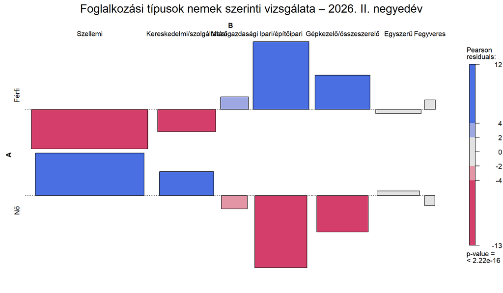

```r
assoc(
  as.matrix(data),
  main = "Foglalkozási típusok nemek szerinti vizsgálata – 2026. II. negyedév",
  shade = TRUE
)
```

# 4 Összehasonlítás az 1990-es órai adatokkal

A feltöltött órai állomány 1990-es adatai a következő táblát adják:

```r
round(data1990, 1)
```

```
##       Szakmunkás Betanított munkás Segédmunkás Szellemi
## Férfi      767.9             302.8       115.7    452.8
## Nő         275.8             343.5       125.1    764.9
```

```r
chi1990 <- chisq.test(as.matrix(data1990), correct = FALSE)
V1990 <- sqrt(
  as.numeric(chi1990$statistic) /
    (sum(as.matrix(data1990)) * min(nrow(data1990) - 1, ncol(data1990) - 1))
)
V1990
```

```
## [1] 0.3138402
```

Az 1990-es táblában Cramer-féle $V = 0.314$, tehát az órai értékelés szerint szintén **laza kapcsolat** volt. A korabeli mintázat szerint a férfiak a szakmunkások, míg a nők a szellemi foglalkozásúak között voltak felülreprezentálva, ami megfelel az eredeti órai megállapításnak.

Mivel a részletes foglalkozási kategóriák időközben megváltoztak, a két részletes Cramer V értéket nem célszerű közvetlenül egymáshoz viszonyítani. A hosszú távú összehasonlítást ezért **fizikai–szellemi** bontásban végezzük el.

```r
# 1990: fizikai = szakmunkás + betanított + segédmunkás
broad1990 <- cbind(
  Fizikai = rowSums(data1990[, c("Szakmunkás", "Betanított munkás", "Segédmunkás")]),
  Szellemi = data1990[, "Szellemi"]
)

# 2026: a KSH által közölt összesítő oszlopok közvetlen használata
broad2026 <- cbind(
  Fizikai = adat2026_raw$`Fizikai foglalkozások összesen`,
  Szellemi = adat2026_raw$`Szellemi foglalkozások összesen`
)
rownames(broad2026) <- adat2026_raw$Nem

pct1990 <- prop.table(broad1990, 1) * 100
pct2026 <- prop.table(broad2026, 1) * 100

chi_broad_1990 <- chisq.test(broad1990, correct = FALSE)
chi_broad_2026 <- chisq.test(broad2026, correct = FALSE)

V_broad_1990 <- sqrt(as.numeric(chi_broad_1990$statistic) / sum(broad1990))
V_broad_2026 <- sqrt(as.numeric(chi_broad_2026$statistic) / sum(broad2026))

osszehasonlitas <- data.frame(
  Mutató = c(
    "Férfiak – szellemi (%)",
    "Nők – szellemi (%)",
    "Férfiak – fizikai (%)",
    "Nők – fizikai (%)",
    "Cramer V (fizikai–szellemi)"
  ),
  `1990-es órai adat` = c(
    pct1990["Férfi", "Szellemi"],
    pct1990["Nő", "Szellemi"],
    pct1990["Férfi", "Fizikai"],
    pct1990["Nő", "Fizikai"],
    V_broad_1990
  ),
  `2026 II. negyedév` = c(
    pct2026["Férfi", "Szellemi"],
    pct2026["Nő", "Szellemi"],
    pct2026["Férfi", "Fizikai"],
    pct2026["Nő", "Fizikai"],
    V_broad_2026
  ),
  check.names = FALSE
)

knitr::kable(osszehasonlitas, digits = 1)
```

| Mutató | 1990-es órai adat | 2026 II. negyedév |
| --- | --- | --- |
| Férfiak – szellemi (%) | 27.6 | 41.9 |
| Nők – szellemi (%) | 50.7 | 64.0 |
| Férfiak – fizikai (%) | 72.4 | 58.1 |
| Nők – fizikai (%) | 49.3 | 36.0 |
| Cramer V (fizikai–szellemi) | 0.2 | 0.2 |

## 4.1 Válasz a házi feladat kérdéseire

### 4.1.1 Milyen összefüggés látható a nem és a foglalkoztatás típusa között?

2026. 2. negyedévében továbbra is **szignifikáns és az órai skála szerint laza kapcsolat** látható a nem és a foglalkozás típusa között. A kapcsolat nem azt jelenti, hogy a nem egyértelműen meghatározza a foglalkozást, hanem azt, hogy egyes foglalkozási csoportokban a férfiak és a nők aránya érdemben eltér a függetlenség esetén várható aránytól.

A mai adatokban a férfiak különösen az **ipari és építőipari**, valamint a **gépkezelői/összeszerelői** csoportokban felülreprezentáltak. A nők a **szellemi**, továbbá a **kereskedelmi és szolgáltatási** foglalkozásokban felülreprezentáltak. Ez azt mutatja, hogy a foglalkozási szerkezetben ma is jelen van a nemek szerinti elkülönülés.

### 4.1.2 Mi és hogyan változott meg az 1990-es felmérések óta?

A legfontosabb változás a foglalkoztatási szerkezet **szellemi foglalkozások felé történő eltolódása mindkét nemnél**:

- a férfiaknál a szellemi foglalkozások aránya 27.6%-ról 41.9%-ra nőtt, vagyis 14.3 százalékponttal;
- a nőknél ugyanez az arány 50.7%-ról 64%-ra nőtt, vagyis 13.3 százalékponttal;
- ezzel párhuzamosan a fizikai foglalkozások aránya mindkét nemnél csökkent.

A széles, fizikai–szellemi bontásban Cramer V 0.237-ról 0.221-ra változott. Ez **kismértékű gyengülést** jelez a nem és a nagyon tágan értelmezett foglalkozástípus közötti kapcsolatban. A nemek közötti különbség azonban nem tűnt el: 2026-ban is jóval nagyobb a szellemi foglalkozások aránya a nők, míg a fizikai foglalkozások aránya a férfiak körében.